# R Notebook

```r
library(tidyverse)
library(janitor)
library(tidycensus)
library(ggplot2)
library(tigris)
```

```r
md_mobile <- read_csv("bdc_24_mobile_broadband_summary_by_geography_place_J25_22nov2025.csv") |> clean_names() |>
  mutate(geography_id = as.character(geography_id))

md_fixed <- read_csv("bdc_24_fixed_broadband_summary_by_geography_place_J25_22nov2025.csv") |> clean_names()

md_county_mobile <- read_csv("bdc_us_mobile_broadband_summary_by_geography_J25_22nov2025.csv") |>
  filter(geography_type == "County") |>
  filter(area_data_type == "Total") |>
  filter(str_detect(geography_desc, "MD"))

variables <- load_variables(2023, "acs5", cache = TRUE)

md_pop <- get_acs(geography = "place",
              variables = c(population = "B01001A_001"),
              state = "MD",
              year = 2023)

md_med_income <- get_acs(geography = "place",
              variables = c(med_income = "B19013_001"),
              state = "MD",
              year = 2023)

md_county_income <- get_acs(geography = "county",
              variables = c(med_income = "B19013_001"),
              state = "MD",
              year = 2023)
```

```r
mobile_by_pop <- md_mobile |>
  filter(str_detect(area_data_type, "Total")) |>
  left_join(md_pop, join_by(geography_id == GEOID)) |>
  select(!c("mobilebb_3g_area_iv_pct", "mobilebb_3g_area_st_pct", "mobilebb_4g_area_st_pct", "mobilebb_4g_area_iv_pct", "mobilebb_5g_spd1_area_iv_pct", "mobilebb_5g_spd1_area_st_pct", "mobilebb_5g_spd2_area_iv_pct"))

mobile_by_income <- md_mobile |>
  filter(str_detect(area_data_type, "Total")) |>
  left_join(md_med_income, join_by(geography_id == GEOID)) |>
  select(!c("mobilebb_3g_area_iv_pct", "mobilebb_3g_area_st_pct", "mobilebb_4g_area_st_pct", "mobilebb_4g_area_iv_pct", "mobilebb_5g_spd1_area_iv_pct", "mobilebb_5g_spd1_area_st_pct", "mobilebb_5g_spd2_area_iv_pct"))

county_by_income <- md_county_mobile |>
   left_join(md_county_income, join_by(geography_id == GEOID)) |>
  select(!c("mobilebb_3g_area_iv_pct", "mobilebb_3g_area_st_pct", "mobilebb_4g_area_st_pct", "mobilebb_4g_area_iv_pct", "mobilebb_5g_spd1_area_iv_pct", "mobilebb_5g_spd1_area_st_pct", "mobilebb_5g_spd2_area_iv_pct"))
```

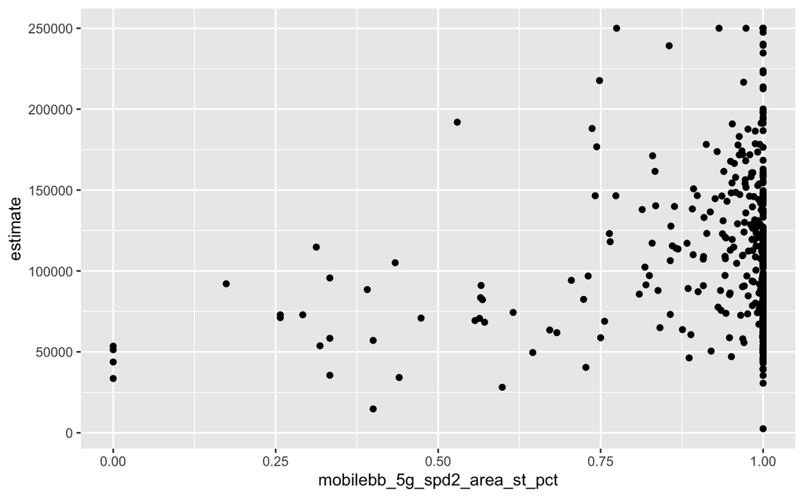

```r
ggplot(mobile_by_income, aes(x=mobilebb_5g_spd2_area_st_pct, y=estimate)) +
  geom_point()
```

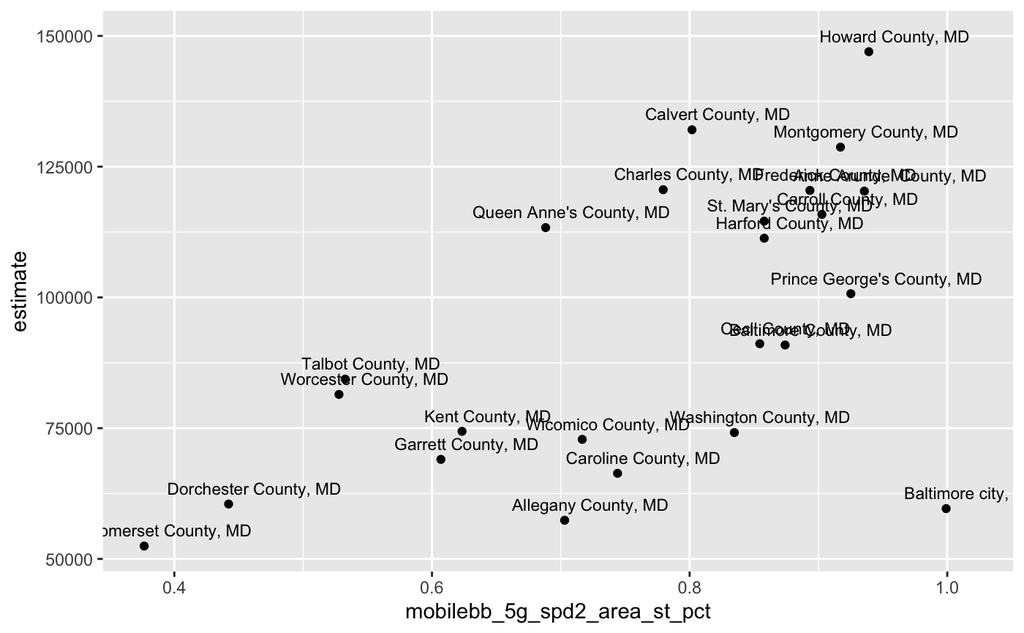

```r
ggplot(county_by_income, aes(x=mobilebb_5g_spd2_area_st_pct, y=estimate)) +
  geom_point() +
  geom_text(aes(label=geography_desc), nudge_x = 0.02, nudge_y = 3000, size = 3)
```

Limitations/challenges so far are that coverage as a whole is pretty good everywhere at this point, so we have to mainly look at the highest speed of mobile coverage, since that is not yet available everywhere. Our broader starting questions about coverage will have to be applied to questions about higher-speed coverage. Also, another challenge we have run into so far is that a lot of the findings we were originally interested in will have very obvious conclusions, like the more populated ares are of course going to have better coverage. That wouldn’t make for a very good story. We’re going to have to get a bit more creative with how we use the data and where we look.

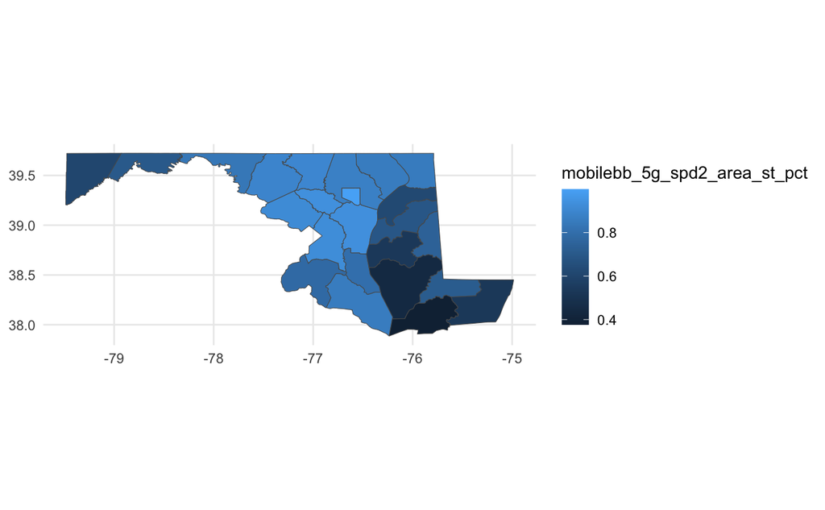

```r
geog_places <- counties(state = 24)

geog_md_counties <- md_county_mobile |>
  left_join(geog_places, join_by(geography_id == GEOID))

ggplot() +
  geom_sf(data = geog_md_counties, aes(fill=mobilebb_5g_spd2_area_st_pct, geometry=geometry)) +
  theme_minimal()
```

```r
NA
NA
```

Our most newsworthy finding at this point is probably that there is a pretty clear pattern of lower-income places being more likely to have worse access to high-speed coverage. Granted, there are plenty of low-income areas that do have great coverage, but there are virtually zero high income areas with poor coverage. If you live in a wealthy area, you probably don;t have to worry about access to high-speed mobile coverage.

There is also a pretty clear divide between the areas to the east and west of the bay. This is interesting, but not surprising.